# House Price Analysis

# Feature Selection:

Note: prints some relevant information as it goes along so you can track the progress.

```r
availPreds <- 1:numPreds
modelPreds <- c()
## keep track of the R2 for reference
maxR2 <- c()
##Keep going as long as there are available predictors left
while(length(availPreds) > 0){
    ##add predictor which increases R^2 the most
    ##keep track of the R^2 values for reference
    allR2 <- c()
    for(id in availPreds){
      ##the augmented predictors
      augPreds <- c(modelPreds,id)
      ## Build the data frame with the augmented predictors
      data.df <- housePrices.df[,c(augPreds,numPreds+1)]
      ##the model and its summary
      mod.curr <- lm(SalePrice ~ .,
                     data=data.df)
      mod.sum <- summary(mod.curr)
      ##grab the R^2
      allR2 <- c(allR2,mod.sum$r.squared)
    }
    ##Find the index of the min R^2
    max.id <- which.max(allR2)
    ##get the best predictor and R^2
    bestPred <- availPreds[max.id]
    bestR2 <- max(allR2)
    ##Add these into the collection
    modelPreds <- c(modelPreds,bestPred)
    ## remove the  bestPred from  the availPreds
    availPreds <- setdiff(availPreds,bestPred)
    maxR2 <- c(maxR2,bestR2)
    ##remove bestsPred from avail
    ## Print stuff out for debugging and attention-grabbing
    print(sprintf("Pred Added: %s  R^2 Value: %s",bestPred,round(bestR2,3)))
    ##print(modelPreds)
}
```

```
## [1] "Pred Added: 3  R^2 Value: 0.657"
## [1] "Pred Added: 23  R^2 Value: 0.72"
## [1] "Pred Added: 10  R^2 Value: 0.75"
## [1] "Pred Added: 11  R^2 Value: 0.781"
## [1] "Pred Added: 13  R^2 Value: 0.794"
## [1] "Pred Added: 5  R^2 Value: 0.803"
## [1] "Pred Added: 18  R^2 Value: 0.811"
## [1] "Pred Added: 30  R^2 Value: 0.817"
## [1] "Pred Added: 4  R^2 Value: 0.821"
## [1] "Pred Added: 20  R^2 Value: 0.824"
## [1] "Pred Added: 29  R^2 Value: 0.827"
## [1] "Pred Added: 22  R^2 Value: 0.829"
## [1] "Pred Added: 7  R^2 Value: 0.831"
## [1] "Pred Added: 2  R^2 Value: 0.834"
## [1] "Pred Added: 6  R^2 Value: 0.835"
```

[output cut: 17 more lines]

It will help to have a help function to compute the cross-validated MSE.

```r
## args: a data frame and a number of folds (default to 10).
## ret: k-fold cross-validated MSE and the Standard Error
data.df <- housePrices.df
mseCV_SE <- function(data.df,numFolds=10){
  dataSize <- nrow(data.df)
  folds <- sample(1:numFolds,dataSize,rep=T)
  mse <- numeric(numFolds)
  for(fold in 1:numFolds){
    train.df <- data.df[folds !=fold,]
    test.df <- data.df[folds==fold,]
    mod <- lm(SalePrice  ~ .,
              data=train.df)
    vals <- predict(mod,newdata=test.df)
    mse[fold] <- with(test.df,mean((SalePrice-vals)^2))
  }
  c(mean(mse),sqrt(var(mse)/numFolds))
}

## and just the CV
mseCV <- function(data.df,numFolds=10){
 mseCV_SE(data.df,numFolds)[1]
}
```

Compute the MSE of all the models from the forward selection

```r
allMSE <- map_dbl(1:(numPreds-0),
                  function(totPred)
                 mseCV(housePrices.df[,c(modelPreds[1:totPred],numPreds+1)]))
```

How’s this look?

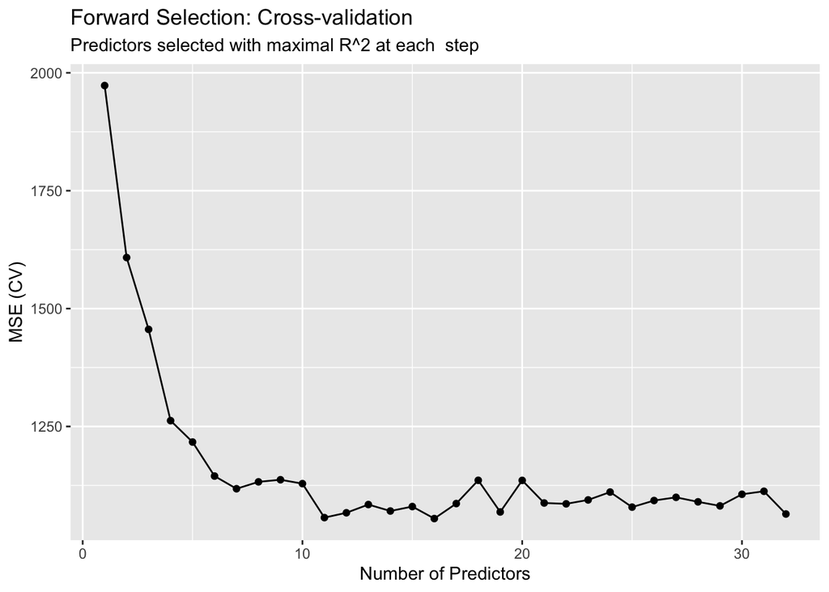

```r
data.frame(numPred=1:(numPreds-0),
           mse=allMSE) %>%
  ggplot()+
  geom_point(aes(numPred,mse))+
  geom_line(aes(numPred,mse))+
  labs(title="Forward Selection: Cross-validation",
       subtitle="Predictors selected with maximal R^2 at each  step",
       x = "Number of Predictors",
       y = "MSE (CV)")
```

```r
(predMin <- which.min(allMSE))
```

```
## [1] 16
```

```r
##build this model
data.df <- housePrices.df[,c(modelPreds[1:predMin],numPreds+1)]
## get  both the MSE  estimate and the SE
(mseInfo <- mseCV_SE(data.df))
```

```
## [1] 1114.7852  146.2353
```

```r
## add the MSE and the SE.
mseCut <- mseInfo[1]+mseInfo[2]
##
(thePreds <- (1:numPreds)[allMSE < mseCut])
```

```
##  [1]  5  6  7  8  9 10 11 12 13 14 15 16 17 18 19 20 21 22 23 24 25 26 27 28 29
## [26] 30 31 32
```

```r
(optNumPreds <- min(thePreds))
```

```
## [1] 5
```

```r
(forwardPreds <- modelPreds[1:optNumPreds])
```

```
## [1]  3 23 10 11 13
```

Interesting, just 5 predictors.

and the resulting estimated MSE

```r
(mse.forward <- allMSE[optNumPreds])
```

```
## [1] 1217
```

# Backward Selection

```r
availPreds <- 1:numPreds
modelPreds <- c()
while(length(availPreds) >1){
  allR2 <- c()
  pred <- 1
  for(pred in availPreds){
    testPreds <- setdiff(availPreds,pred)
     # data.df <- house.df[,c(augPreds,numPreds+1)]
     #  ##the model and its summary
     #  mod.curr <- lm(SalePrice ~ .,
     #                 data=data.df)
     #

    data.df <- housePrices.df[,c(testPreds,numPreds+1)]
    mod <- lm(SalePrice ~ ., data=data.df)
    mod.sum <- summary(mod)
    allR2 <- c(allR2,mod.sum$r.squared)
  }
  max.id <- which.max(allR2)
  bestPred <- availPreds[max.id]
  ##tack the best predictor on the front
  modelPreds <- c(bestPred,modelPreds)
  availPreds <- setdiff(availPreds,bestPred)
  print(sprintf("Pred Added: %s  R^2 Value: %s",bestPred,round(allR2[max.id],3)))
}
```

```
## [1] "Pred Added: 16  R^2 Value: 0.843"
## [1] "Pred Added: 25  R^2 Value: 0.843"
## [1] "Pred Added: 21  R^2 Value: 0.843"
## [1] "Pred Added: 15  R^2 Value: 0.843"
## [1] "Pred Added: 31  R^2 Value: 0.843"
## [1] "Pred Added: 32  R^2 Value: 0.843"
## [1] "Pred Added: 27  R^2 Value: 0.843"
## [1] "Pred Added: 14  R^2 Value: 0.842"
## [1] "Pred Added: 12  R^2 Value: 0.842"
## [1] "Pred Added: 1  R^2 Value: 0.842"
## [1] "Pred Added: 26  R^2 Value: 0.842"
## [1] "Pred Added: 24  R^2 Value: 0.841"
## [1] "Pred Added: 17  R^2 Value: 0.84"
## [1] "Pred Added: 19  R^2 Value: 0.839"
## [1] "Pred Added: 28  R^2 Value: 0.838"
```

[output cut: 16 more lines]

```r
## Tack the last one on the front
modelPreds <- c(availPreds,modelPreds)
```

Cross-validate the MSE

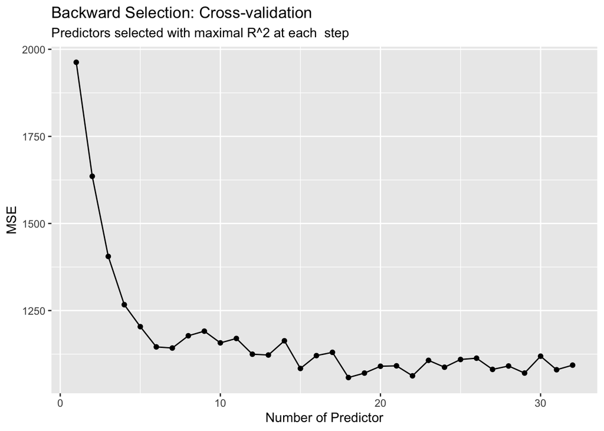

```r
allMSE <- map_dbl(1:numPreds, function(tot)
  mseCV(housePrices.df[,c(modelPreds[1:tot],numPreds+1)]))

###
data.frame(numPreds=1:numPreds,MSE=allMSE) %>%
  ggplot()+
  geom_point(aes(numPreds,MSE))+
  geom_line(aes(numPreds,MSE))+
  labs(title="Backward Selection: Cross-validation",
       subtitle="Predictors selected with maximal R^2 at each  step",
       x="Number of Predictor")
```

1 SE Rule

```r
(predMin <- which.min(allMSE) )
```

```
## [1] 18
```

```r
##build this model
data.df <- housePrices.df[,c(modelPreds[1:predMin],numPreds+1)]
## get  both the MSE  estimate and the SE
(mseInfo <- mseCV_SE(data.df))
```

```
## [1] 1087.1810  168.1864
```

```r
## add the MSE and the SE.
mseCut <- mseInfo[1]+mseInfo[2]
##
(thePreds <- (1:numPreds)[allMSE < mseCut])
```

```
##  [1]  5  6  7  8  9 10 11 12 13 14 15 16 17 18 19 20 21 22 23 24 25 26 27 28 29
## [26] 30 31 32
```

```r
(optNumPreds <- min(thePreds))
```

```
## [1] 5
```

```r
(backwardPreds <- modelPreds[1:optNumPreds])
```

```
## [1]  3 10 11 22 18
```

```r
(mse.backward <- allMSE[optNumPreds])
```

```
## [1] 1203.829
```

```r
dictionary.df[backwardPreds,]
```

```
##      column_name                    description
## 3   Overall.Qual          Overall House Quality
## 10   X1st.Flr.SF            First Floor Sq Feet
## 11   X2nd.Flr.SF           Second Floor Sq Feet
## 22   Garage.Cars Size of garage in car capacity
## 18 Kitchen.AbvGr         Kitchens Above Groiund
```

How do these compare

```r
forwardPreds
```

```
## [1]  3 23 10 11 13
```

```r
backwardPreds
```

```
## [1]  3 10 11 22 18
```

all four comparison

```r
c(mse.backward,mse.forward,mse.knn,msewin.lm)
```

```
##  [1] 1203.829240 1216.999643    1.738806 1115.143184    1.000000    2.000000
##  [7]    3.000000    4.000000    5.000000    6.000000    7.000000    8.000000
## [13]    9.000000   10.000000   11.000000   12.000000   13.000000   14.000000
## [19]   15.000000   16.000000   17.000000   18.000000   19.000000   20.000000
## [25]   21.000000   22.000000   23.000000   24.000000   25.000000   26.000000
## [31]   27.000000   28.000000   29.000000   30.000000   31.000000   32.000000
```

```r
#we can get our winner KNN here.
```

#Now we headed to our last model: #Penalized regression We also need a grid of lambda values. It is important to remember that there is no natural scale for the lambda values. I settled on this grid after some experimentation.

Set up the data

```r
numPreds <- ncol(housePrices.df)-1
data.x <- data.matrix(housePrices.df[,-(numPreds+1)])
data.y <- data.matrix(housePrices.df[,numPreds+1])
```

```r
lambda.grid <- 10^seq(-1,2,length=100)
```

### Cross-validation and lambda selection

Now we can run cross-validated lasso and look at the results.

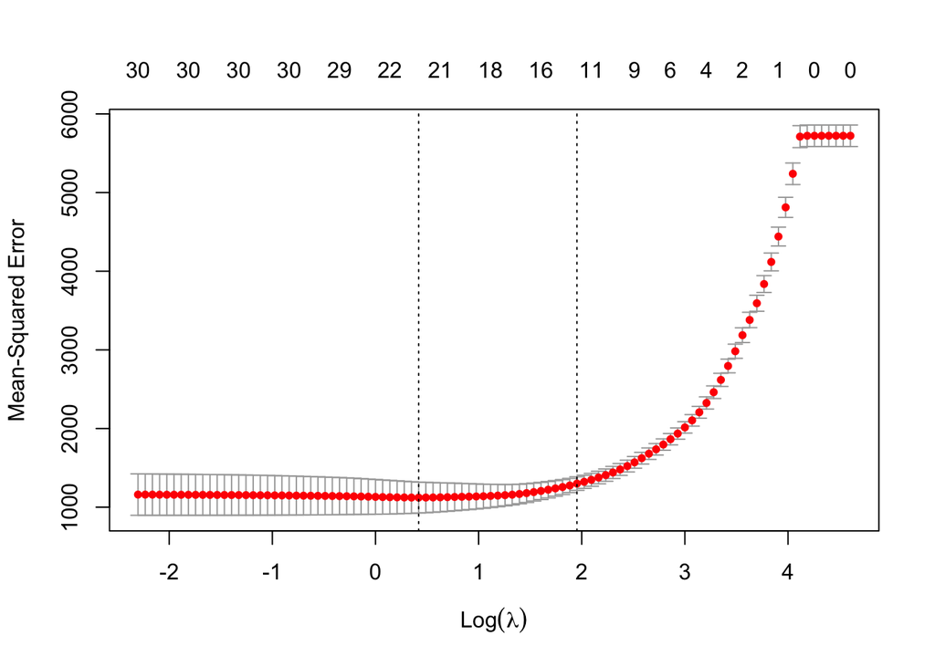

```r
mod.lasso.cv <- cv.glmnet(data.x,
                          data.y,
                          alpha=1,
                          lambda=lambda.grid)

plot(mod.lasso.cv)
```

From the plot, we see both the lambda with the minimal MSE and the “One SE Rule” lambd.

Use the “One SE Rule” lambda value since it will use fewer predictors

```r
##lambda.opt <- mod.lasso.cv$lambda.min
(lambda.opt <- mod.lasso.cv$lambda.1se)
```

```
## [1] 7.054802
```

### Optimal Lasso Model

Now let’s look at which of these variables are nonzero at the optimal lambda value.

```r
mod.lasso.opt <- glmnet(data.x,
                    data.y,
                    alpha=1,
                    lambda=lambda.opt)
```

Grab the coefficients and drop the constant term.

```r
coefs.lasso <- data.matrix(coefficients(mod.lasso.cv,s=lambda.opt))
coefs.lasso <- coefs.lasso[-1] ##drop constant term
lassoPreds <- which(coefs.lasso != 0)
```

```r
id <- which(mod.lasso.cv$lambda == lambda.opt)
(mse.lasso <- mod.lasso.cv$cvm[id])
```

```
## [1] 1299.896
```

```r
c(mse.forward,mse.backward,mse.lasso,mse.knn,msewin.lm)
```

```
##  [1] 1216.999643 1203.829240 1299.896434    1.738806 1115.143184    1.000000
##  [7]    2.000000    3.000000    4.000000    5.000000    6.000000    7.000000
## [13]    8.000000    9.000000   10.000000   11.000000   12.000000   13.000000
## [19]   14.000000   15.000000   16.000000   17.000000   18.000000   19.000000
## [25]   20.000000   21.000000   22.000000   23.000000   24.000000   25.000000
## [31]   26.000000   27.000000   28.000000   29.000000   30.000000   31.000000
## [37]   32.000000
```